# Assignment3_RNAseq

MOrteza Jafari

## Assignment 3 - Instructions

In this assignment you will perform analysis of RNA-seq data, with focus on the downstream analysis in R. Thus, quality control, trimming and read alignment will not be covered in this assignment. A raw count matrix has been provided to you. These data consist of read counts generated from human embryonic stem cells (hESCs). There are samples that have been treated with a substance called CHIR which activates a signaling pathway important in many cellular functions. There are also some untreated control samples.

This RMD file acts as a template in which fragments of the analysis code have already been written, but there are parts missing. - Your task is to complete (and sometimes correct) the code and ensure that it can be executed correctly. - Additionally, there are some questions which you should respond to after the “Answer:” text.

Important notes: - Do not forget to submit the completed HTML report file in the submission section on the Lisam page. - Add your name to the HTML file name. - Remember to check that the HTML file looks as expected before submitting it.

## SETUP

If you are working on the Sigma HPC, the first thing you need to do is to point R to the folder in which the packages have been pre-installed (NOTE: this step is not needed if you are working on your own computer).

```r
.libPaths("/proj/liu-compute-2023-21/RNA-seq/lib/R/library")
```

Next, load the R packages.

```r
library(dplyr)
```

```r
library(ggplot2)
library(DESeq2)
library(clusterProfiler)
library(org.Hs.eg.db)
library(rtracklayer)
library(AnnotationDbi)
```

## Read data

Now read the count matrix into R. Remember that the rownames should be the gene ids. Also remove genes that have not counts in any sample.

```r
# Load the count matrix into R
CountData <- read.table("D:/LiU/Masters/Bioinformatics/RNA seq/Data/hESC_raw_counts_matrix.txt", header = TRUE, sep = '\t')

# Check the first few rows to identify gene identifiers
head(CountData)
```

```
##           gene_name hESC_CHIR_24h_A hESC_CHIR_24h_B hESC_CHIR_24h_C hESC_CTRL_A
## 1 ENSG00000223972.5               9               5               5           0
## 2 ENSG00000227232.5               4               6              14          19
## 3 ENSG00000278267.1               0               0               0           0
## 4 ENSG00000243485.5               0               4               0           0
## 5 ENSG00000284332.1               0               0               0           0
## 6 ENSG00000237613.2               0               0               0           0
##   hESC_CTRL_B hESC_CTRL_C
## 1           3           3
## 2          16           7
## 3           0           0
## 4           0           0
## 5           0           0
## 6           0           0
```

```r
# Count total number of genes before filtering
total_genes_before <- nrow(CountData)

# Assuming the first column contains gene IDs
rownames(CountData) <- CountData[,1]

# Remove the column with gene IDs
CountData <- CountData[,-1]

# Filter out genes with zero counts across all samples
CountData <- CountData[apply(CountData, 1, function(x) !all(x == 0)),]

# Count total number of genes after filtering
total_genes_after <- nrow(CountData)

# Calculate the number of genes removed
genes_removed <- total_genes_before - total_genes_after
```

**Question 2:** What type of gene identifiers are used in this data?  
**Answer:** The gene identifiers are Ensembl IDs  
**Question 3:** How many genes with zero counts were removed?  
**Answer:** 30540

Next, we also read in some annotation data from which we can add additional gene identifiers to our data at a later stage.

```r
# Load the GTF file
gtf <- rtracklayer::import('D:/LiU/Masters/Bioinformatics/RNA seq/Data/Homo_sapiens.GRCh38.110.gtf')

# Subsetting the gtf object to keep only 'gene_id' and 'gene_name' in metadata
mcols(gtf) <- mcols(gtf)[, c("gene_id", "gene_name")]

# Remove duplicated rows based on the metadata columns
gtf <- gtf[!duplicated(mcols(gtf)),]

# Convert gtf GRanges object to a data frame
gtf <- as.data.frame(gtf)
```

Lastly, we read in the sample information file.

```r
# Read in the sample information file
SampleInfo <- read.table("D:/LiU/Masters/Bioinformatics/RNA seq/Data/hESC_SampleInfo.txt", header = TRUE, sep = '\t')

# Convert the 'Group' column to a factor
SampleInfo$Group <- factor(SampleInfo$Group)
```

## Main analysis

Now its time to construct the necessary object and run the differential expression analysis.

```r
# Construct the DESeqDataSet object
# Ensure 'CountData' is your count matrix and 'SampleInfo' is your sample info dataframe
dds <- DESeqDataSetFromMatrix(countData = CountData, colData = SampleInfo, design = ~ Group)

# Run the DESeq differential expression analysis
dds <- DESeq(dds)
```

Next, perform PCA.

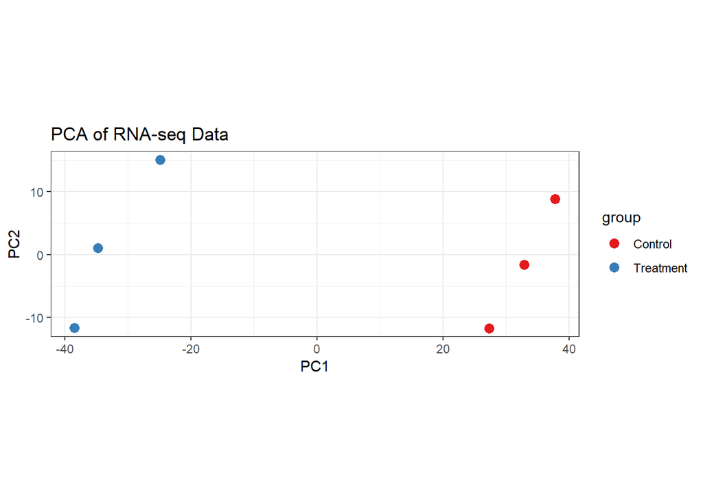

```r
# Apply the variance stabilizing transformation
dds_de_vst <- vst(dds, blind = FALSE)

# Perform and plot PCA with improvements
pca_plot <- plotPCA(dds_de_vst, intgroup = c("Group"), ntop = 2000) +
  theme_bw() +
  ggtitle("PCA of RNA-seq Data") +  # Add a title
  xlab("PC1") +  # Label for x-axis
  ylab("PC2") +  # Label for y-axis
  geom_point(size = 3) +  # Increase point size
  scale_color_brewer(palette = "Set1") +  # Use a different color palette
  theme(legend.position = "right")  # Adjust legend position

# To display the plot
print(pca_plot)
```

Extract the results of the differential expression analysis.

```r
# Extracting differential expression results
DEres <- results(dds, contrast = c("Group", "Treatment", "Control"))
DEres$padj[is.na(DEres$padj)] <- 1

# Convert DESeq results to a data frame
DEres_df <- as.data.frame(DEres)

# Ensure that row names of DEres_df are set for merging (gene IDs)
rownames(DEres_df) <- rownames(mcols(dds))

# Remove version numbers from gene IDs in DEres_df
rownames(DEres_df) <- gsub("\\..*", "", rownames(DEres_df))

# Merge with GTF data frame
DEres_merged <- merge(DEres_df, gtf, by.x = "row.names", by.y = "gene_id")

# Now, let's check the merged data
head(DEres_merged)
```

```
##         Row.names    baseMean log2FoldChange     lfcSE      stat       pvalue
## 1 ENSG00000000003 5158.971023     0.15644966 0.1265620  1.236150 2.164028e-01
## 2 ENSG00000000005   94.504415     1.73097826 0.2665499  6.494012 8.357988e-11
## 3 ENSG00000000419 1554.888946     0.58446778 0.1533414  3.811546 1.381006e-04
## 4 ENSG00000000457  237.847006     0.68752054 0.1920265  3.580343 3.431441e-04
## 5 ENSG00000000460  959.849717     0.06775083 0.1453023  0.466275 6.410187e-01
## 6 ENSG00000000938    2.886633    -2.18621606 1.3934701 -1.568901 1.166711e-01
##           padj seqnames     start       end  width strand gene_name
## 1 3.993807e-01        X 100627108 100639991  12884      -    TSPAN6
## 2 1.745709e-09        X 100584936 100599885  14950      +      TNMD
## 3 1.000235e-03       20  50934867  50959140  24274      -      DPM1
## 4 2.211925e-03        1 169849631 169894267  44637      -     SCYL3
## 5 7.963664e-01        1 169662007 169854080 192074      +  C1orf112
## 6 2.564342e-01        1  27612064  27635185  23122      -       FGR
```

```r
# Gene with the highest log2FoldChange
highest_lfc_gene <- DEres_merged[which.max(DEres_merged$log2FoldChange),]

# Gene with the lowest log2FoldChange
lowest_lfc_gene <- DEres_merged[which.min(DEres_merged$log2FoldChange),]
```

**Question 4:** Which gene shows the highest log2FoldChange, and which gene shows the lowest?  
**Answer:** Highest: ENSG00000113722 and lowest:  
ENSG00000204684.

## Data visualization

Create a volcano plot that shows significant up-and down-regulated genes.

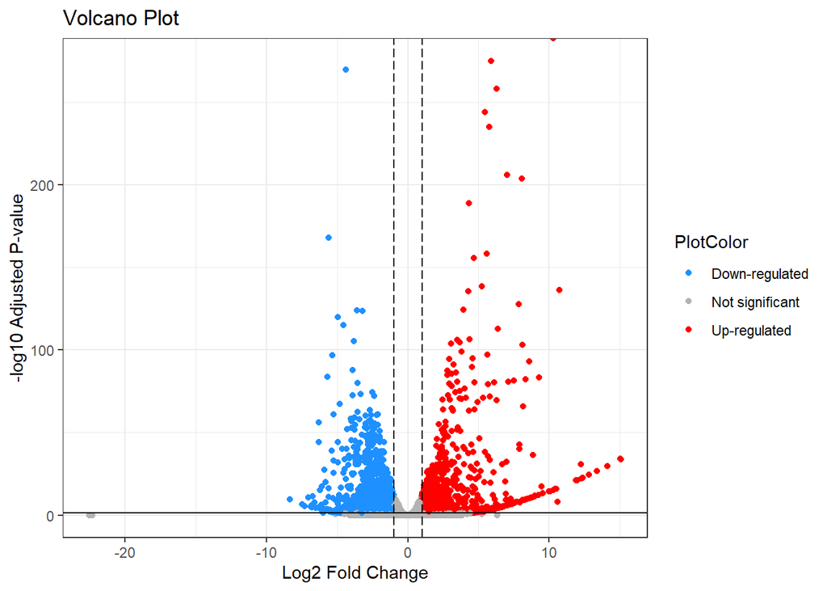

```r
# Convert DESeq results to a data frame
DEres_df <- as.data.frame(DEres)

# Set the adjusted p-value threshold
p_threshold <- 0.05  # You can adjust this threshold as needed

# Define the PlotColor based on significance and fold change in DEres_df
DEres_df$PlotColor <- ifelse(DEres_df$padj < p_threshold & DEres_df$log2FoldChange < -1, "Down-regulated",
                             ifelse(DEres_df$padj < p_threshold & DEres_df$log2FoldChange > 1, "Up-regulated", "Not significant"))

# Create the volcano plot using ggplot2
library(ggplot2)
ggplot(DEres_df, aes(x = log2FoldChange, y = -log10(padj), color = PlotColor)) +
  geom_point() +
  geom_vline(xintercept = c(-1, 1), color = "black", linetype = "longdash") +
  geom_hline(yintercept = -log10(p_threshold), color = "black") +
  scale_color_manual(values = c("Down-regulated" = "dodgerblue", "Up-regulated" = "red", "Not significant" = "grey70")) +
  theme_bw() +
  labs(title = "Volcano Plot", x = "Log2 Fold Change", y = "-log10 Adjusted P-value")
```

```r
# Count significantly up- and down-regulated genes at different p-value thresholds
count_significant_genes <- function(p_threshold) {
  up_regulated_count <- sum(DEres_df$padj < p_threshold & DEres_df$log2FoldChange > 1)   # Up-regulated
  down_regulated_count <- sum(DEres_df$padj < p_threshold & DEres_df$log2FoldChange < -1)  # Down-regulated
  return(list(Up = up_regulated_count, Down = down_regulated_count))
}

# Counting genes using different p-value thresholds
counts_at_p_01 <- count_significant_genes(0.01)
counts_at_p_01
```

```
## $Up
## [1] 980
##
## $Down
## [1] 1481
```

```r
counts_at_p_1 <- count_significant_genes(0.1)
counts_at_p_1
```

```
## $Up
## [1] 1360
##
## $Down
## [1] 2026
```

## Enrichment analysis

Lasly, perform pathway enrichment analysis and visualize the results.

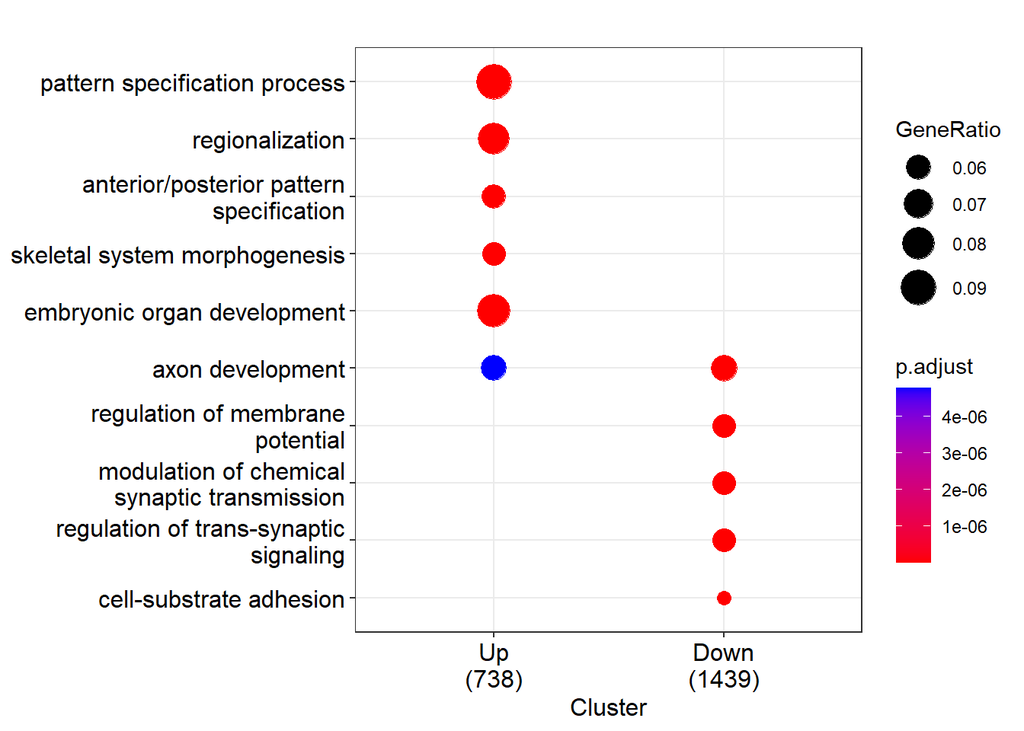

```r
# Remove version numbers from Ensembl IDs and map to ENTREZ IDs
ensembl_ids <- gsub("\\..*", "", rownames(DEres_df))
DEres_df$ENTREZID <- mapIds(org.Hs.eg.db, keys = ensembl_ids, column = "ENTREZID", keytype = "ENSEMBL", multiVals = "first")
# Extract only the up-regulated genes
DEGup <- DEres_df[DEres_df$PlotColor == "Up-regulated", "ENTREZID"]
DEGup <- DEGup[complete.cases(DEGup)]

# Extract only the down-regulated genes
DEGdown <- DEres_df[DEres_df$PlotColor == "Down-regulated", "ENTREZID"]
DEGdown <- DEGdown[complete.cases(DEGdown)]

# Put the up- and down-regulated gene groups in a named list
GeneGroups <- list(Up = DEGup, Down = DEGdown)

# Run enrichment analysis to compare the two groups, focusing on biological pathways
enrichment_results <- compareCluster(geneClusters = GeneGroups, fun = "enrichGO", OrgDb = org.Hs.eg.db, ont = "BP")

# Visualize the results in a dotplot
dotplot(enrichment_results, showCategory = 5)
```